# SeqMonk Vistory Report

[figure not shown]

## Project Summary

### Basic Project Info

| Parameter | Value |
| --- | --- |
| Project Name | pluripotency_exit_DNMT_Epi_ChIP.smk |
| Vistory Name | pluripotency_exit_DNMT_Epi_K27ac_pmQC.smv |
| Genome | Mus musculus GRCm38_v95 |
| SeqMonk Version | 1.46.0 |

### Data Sets

| Name | File Name | Reads | Import Options |
| --- | --- | --- | --- |
| ATAC_DNMT_KO_Epi_1 | Reimported from ATAC_DNMT_KO_Epi_1 | 7113690 | Visible stores parser Filter by feature Excluding excluded_regions_all_input_200425.txt Remove DuplicatesNo |
| ATAC_DNMT_KO_Epi_2 | Reimported from ATAC_DNMT_KO_Epi_2 | 5547643 | Visible stores parser Filter by feature Excluding excluded_regions_all_input_200425.txt Remove DuplicatesNo |
| ATAC_DNMT_KO_Epi_3 | Reimported from ATAC_DNMT_KO_Epi_3 | 5522265 | Visible stores parser Filter by feature Excluding excluded_regions_all_input_200425.txt Remove DuplicatesNo |
| ATAC_DNMT_KO_ES_1 | Reimported from ATAC_DNMT_KO_ES_1 | 6125661 | Visible stores parser Filter by feature Excluding excluded_regions_all_input_200425.txt Remove DuplicatesNo |
| ATAC_DNMT_KO_ES_2 | Reimported from ATAC_DNMT_KO_ES_2 | 5027523 | Visible stores parser Filter by feature Excluding excluded_regions_all_input_200425.txt Remove DuplicatesNo |
| ATAC_DNMT_KO_ES_3 | Reimported from ATAC_DNMT_KO_ES_3 | 5026670 | Visible stores parser Filter by feature Excluding excluded_regions_all_input_200425.txt Remove DuplicatesNo |
| ATAC_DNMT_WT_Epi_1 | Reimported from ATAC_DNMT_WT_Epi_1 | 5413360 | Visible stores parser Filter by feature Excluding excluded_regions_all_input_200425.txt Remove DuplicatesNo |
| ATAC_DNMT_WT_Epi_2 | Reimported from ATAC_DNMT_WT_Epi_2 | 4775153 | Visible stores parser Filter by feature Excluding excluded_regions_all_input_200425.txt Remove DuplicatesNo |
| ATAC_DNMT_WT_Epi_3 | Reimported from ATAC_DNMT_WT_Epi_3 | 4936556 | Visible stores parser Filter by feature Excluding excluded_regions_all_input_200425.txt Remove DuplicatesNo |
| ATAC_DNMT_WT_ES_1 | Reimported from ATAC_DNMT_WT_ES_1 | 5973065 | Visible stores parser Filter by feature Excluding excluded_regions_all_input_200425.txt Remove DuplicatesNo |
| ATAC_DNMT_WT_ES_2 | Reimported from ATAC_DNMT_WT_ES_2 | 5012136 | Visible stores parser Filter by feature Excluding excluded_regions_all_input_200425.txt Remove DuplicatesNo |
| ATAC_DNMT_WT_ES_3 | Reimported from ATAC_DNMT_WT_ES_3 | 7445720 | Visible stores parser Filter by feature Excluding excluded_regions_all_input_200425.txt Remove DuplicatesNo |
| CTCF_DNMT_KO_Epi_1 | Reimported from CTCF_DNMT_KO_Epi_1 | 23334028 | Visible stores parser Filter by feature Excluding excluded_regions_all_input_200425.txt Remove DuplicatesNo |
| CTCF_DNMT_KO_Epi_2 | Reimported from CTCF_DNMT_KO_Epi_2 | 29180491 | Visible stores parser Filter by feature Excluding excluded_regions_all_input_200425.txt Remove DuplicatesNo |
| CTCF_DNMT_KO_Epi_3 | Reimported from CTCF_DNMT_KO_Epi_3 | 25907443 | Visible stores parser Filter by feature Excluding excluded_regions_all_input_200425.txt Remove DuplicatesNo |
| CTCF_DNMT_KO_ES_1 | Reimported from CTCF_DNMT_KO_ES_1 | 18454754 | Visible stores parser Filter by feature Excluding excluded_regions_all_input_200425.txt Remove DuplicatesNo |
| CTCF_DNMT_KO_ES_2 | Reimported from CTCF_DNMT_KO_ES_2 | 21974831 | Visible stores parser Filter by feature Excluding excluded_regions_all_input_200425.txt Remove DuplicatesNo |
| CTCF_DNMT_KO_ES_3 | Reimported from CTCF_DNMT_KO_ES_3 | 22701344 | Visible stores parser Filter by feature Excluding excluded_regions_all_input_200425.txt Remove DuplicatesNo |
| CTCF_DNMT_WT_Epi_1 | Reimported from CTCF_DNMT_WT_Epi_1 | 26298680 | Visible stores parser Filter by feature Excluding excluded_regions_all_input_200425.txt Remove DuplicatesNo |
| CTCF_DNMT_WT_Epi_2 | Reimported from CTCF_DNMT_WT_Epi_2 | 20824648 | Visible stores parser Filter by feature Excluding excluded_regions_all_input_200425.txt Remove DuplicatesNo |
| CTCF_DNMT_WT_Epi_3 | Reimported from CTCF_DNMT_WT_Epi_3 | 22115922 | Visible stores parser Filter by feature Excluding excluded_regions_all_input_200425.txt Remove DuplicatesNo |
| CTCF_DNMT_WT_ES_1 | Reimported from CTCF_DNMT_WT_ES_1 | 18591373 | Visible stores parser Filter by feature Excluding excluded_regions_all_input_200425.txt Remove DuplicatesNo |
| CTCF_DNMT_WT_ES_2 | Reimported from CTCF_DNMT_WT_ES_2 | 23250934 | Visible stores parser Filter by feature Excluding excluded_regions_all_input_200425.txt Remove DuplicatesNo |
| CTCF_DNMT_WT_ES_3 | Reimported from CTCF_DNMT_WT_ES_3 | 19583044 | Visible stores parser Filter by feature Excluding excluded_regions_all_input_200425.txt Remove DuplicatesNo |
| H3K27Ac_DNMT_KO_Epi_1 | Reimported from H3K27Ac_DNMT_KO_Epi_1 | 35150191 | Visible stores parser Filter by feature Excluding excluded_regions_all_input_200425.txt Remove DuplicatesNo |
| H3K27Ac_DNMT_KO_Epi_2 | Reimported from H3K27Ac_DNMT_KO_Epi_2 | 15686066 | Visible stores parser Filter by feature Excluding excluded_regions_all_input_200425.txt Remove DuplicatesNo |
| H3K27Ac_DNMT_KO_Epi_3 | Reimported from H3K27Ac_DNMT_KO_Epi_3 | 32506101 | Visible stores parser Filter by feature Excluding excluded_regions_all_input_200425.txt Remove DuplicatesNo |
| H3K27Ac_DNMT_KO_ES_1 | Reimported from H3K27Ac_DNMT_KO_ES_1 | 25969291 | Visible stores parser Filter by feature Excluding excluded_regions_all_input_200425.txt Remove DuplicatesNo |
| H3K27Ac_DNMT_KO_ES_2 | Reimported from H3K27Ac_DNMT_KO_ES_2 | 29683025 | Visible stores parser Filter by feature Excluding excluded_regions_all_input_200425.txt Remove DuplicatesNo |
| H3K27Ac_DNMT_KO_ES_3 | Reimported from H3K27Ac_DNMT_KO_ES_3 | 26980378 | Visible stores parser Filter by feature Excluding excluded_regions_all_input_200425.txt Remove DuplicatesNo |

[output cut: 54 more lines]

### Replicate Sets

| ATAC_DNMT_KO_Epi | ATAC_DNMT_KO_ES | CTCF_DNMT_KO_Epi | CTCF_DNMT_KO_ES | CTCF_DNMT_WT_Epi | CTCF_DNMT_WT_ES | H3K27Ac_DNMT_KO_Epi | H3K27Ac_DNMT_KO_ES | H3K27Ac_DNMT_WT_Epi | H3K27Ac_DNMT_WT_ES | H3K27me3_DNMT_KO_Epi | H3K27me3_DNMT_KO_ES | H3K27me3_DNMT_WT_Epi | H3K27me3_DNMT_WT_ES | H3K4me1_DNMT_KO_Epi | H3K4me1_DNMT_KO_ES | H3K4me1_DNMT_WT_Epi | H3K4me1_DNMT_WT_ES | H3K4me3_DNMT_KO_Epi | H3K4me3_DNMT_KO_ES | H3K4me3_DNMT_WT_Epi | H3K4me3_DNMT_WT_ES | Input_DNMT_KO_Epi | Input_DNMT_KO_ES | Input_DNMT_WT_Epi | Input_DNMT_WT_ES |
| --- | --- | --- | --- | --- | --- | --- | --- | --- | --- | --- | --- | --- | --- | --- | --- | --- | --- | --- | --- | --- | --- | --- | --- | --- | --- |
| ATAC_DNMT_KO_Epi_1 | ATAC_DNMT_KO_ES_1 | CTCF_DNMT_KO_Epi_1 | CTCF_DNMT_KO_ES_1 | CTCF_DNMT_WT_Epi_1 | CTCF_DNMT_WT_ES_1 | H3K27Ac_DNMT_KO_Epi_1 | H3K27Ac_DNMT_KO_ES_1 | H3K27Ac_DNMT_WT_Epi_1 | H3K27Ac_DNMT_WT_ES_1 | H3K27me3_DNMT_KO_Epi_1 | H3K27me3_DNMT_KO_ES_1 | H3K27me3_DNMT_WT_Epi_1 | H3K27me3_DNMT_WT_ES_1 | H3K4me1_DNMT_KO_Epi_1 | H3K4me1_DNMT_KO_ES_1 | H3K4me1_DNMT_WT_Epi_1 | H3K4me1_DNMT_WT_ES_1 | H3K4me3_DNMT_KO_Epi_1 | H3K4me3_DNMT_KO_ES_1 | H3K4me3_DNMT_WT_Epi_1 | H3K4me3_DNMT_WT_ES_1 | Input_DNMT_KO_Epi_1 | Input_DNMT_KO_ES_1 | Input_DNMT_WT_Epi_1 | Input_DNMT_WT_ES_1 |
| ATAC_DNMT_KO_Epi_2 | ATAC_DNMT_KO_ES_2 | CTCF_DNMT_KO_Epi_2 | CTCF_DNMT_KO_ES_2 | CTCF_DNMT_WT_Epi_2 | CTCF_DNMT_WT_ES_2 | H3K27Ac_DNMT_KO_Epi_2 | H3K27Ac_DNMT_KO_ES_2 | H3K27Ac_DNMT_WT_Epi_2 | H3K27Ac_DNMT_WT_ES_2 | H3K27me3_DNMT_KO_Epi_2 | H3K27me3_DNMT_KO_ES_2 | H3K27me3_DNMT_WT_Epi_2 | H3K27me3_DNMT_WT_ES_2 | H3K4me1_DNMT_KO_Epi_2 | H3K4me1_DNMT_KO_ES_2 | H3K4me1_DNMT_WT_Epi_2 | H3K4me1_DNMT_WT_ES_2 | H3K4me3_DNMT_KO_Epi_2 | H3K4me3_DNMT_KO_ES_2 | H3K4me3_DNMT_WT_Epi_2 | H3K4me3_DNMT_WT_ES_2 | Input_DNMT_KO_Epi_2 | Input_DNMT_KO_ES_2 | Input_DNMT_WT_Epi_2 | Input_DNMT_WT_ES_2 |
| ATAC_DNMT_KO_Epi_3 | ATAC_DNMT_KO_ES_3 | CTCF_DNMT_KO_Epi_3 | CTCF_DNMT_KO_ES_3 | CTCF_DNMT_WT_Epi_3 | CTCF_DNMT_WT_ES_3 | H3K27Ac_DNMT_KO_Epi_3 | H3K27Ac_DNMT_KO_ES_3 | H3K27Ac_DNMT_WT_Epi_3 | H3K27Ac_DNMT_WT_ES_3 | H3K27me3_DNMT_KO_Epi_3 | H3K27me3_DNMT_KO_ES_3 | H3K27me3_DNMT_WT_Epi_3 | H3K27me3_DNMT_WT_ES_3 | H3K4me1_DNMT_KO_Epi_3 | H3K4me1_DNMT_KO_ES_3 | H3K4me1_DNMT_WT_Epi_3 | H3K4me1_DNMT_WT_ES_3 | H3K4me3_DNMT_KO_Epi_3 | H3K4me3_DNMT_KO_ES_3 | H3K4me3_DNMT_WT_Epi_3 | H3K4me3_DNMT_WT_ES_3 | Input_DNMT_KO_Epi_3 | Input_DNMT_KO_ES_3 | Input_DNMT_WT_Epi_3 | Input_DNMT_WT_ES_3 |

### Quantitation

| Name | Parent | Probes | Description | Comments |
| --- | --- | --- | --- | --- |
| 2 kb tiles |  | 1362779 | Running windows of size 2000 with step size 2000. Quantitated with Read Count Quantitation using All Reads correcting for total count per million reads log transformed |  |

### cumulative distributions

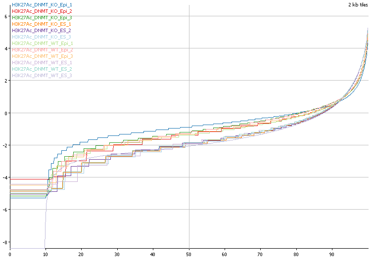

Looks like two different groups of distributions? Ah, and there's the samples which has a lot more reads ...

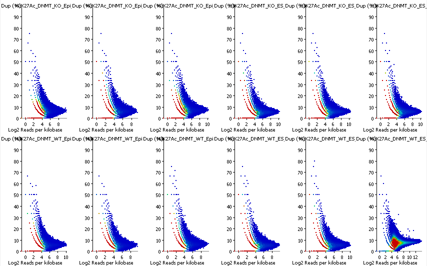

looks ok

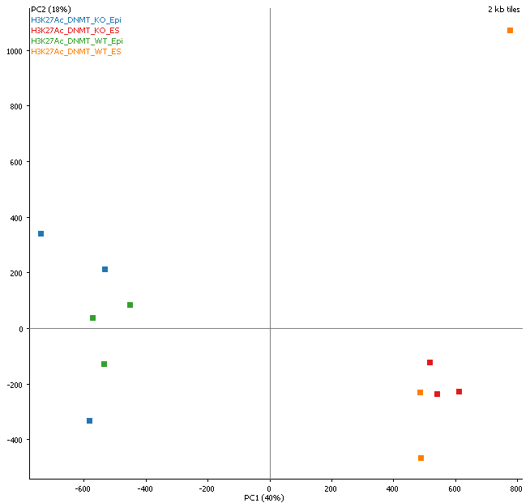

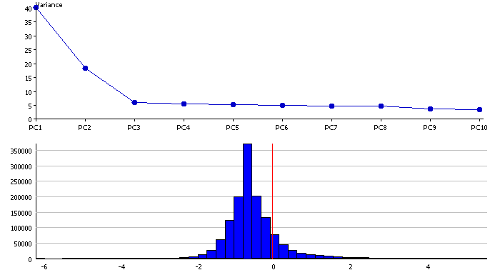

| DataStore | Total Read Count | Forward Read Count | Reverse Read Count | Unknown Read Count | Mean Read Length | Total Read Length | Fold Coverage | Total Quantitation | Median Quantitation | Mean Quantitation | Valid Quantitations |
| --- | --- | --- | --- | --- | --- | --- | --- | --- | --- | --- | --- |
| H3K27Ac_DNMT_KO_Epi_1 | 35150191 | 17572438 | 17577753 | 0 | 273 | 9626765582 | 3.532061101739262 | -1572429.3935115738 | -0.8875331 | -1.1538403 | 1362779 |
| H3K27Ac_DNMT_KO_Epi_2 | 15686066 | 7843830 | 7842236 | 0 | 270 | 4248721162 | 1.5588561516960637 | -1948445.4318254478 | -1.3864491 | -1.4297589 | 1362779 |
| H3K27Ac_DNMT_KO_Epi_3 | 32506101 | 16255026 | 16251075 | 0 | 261 | 8507957410 | 3.1215702893299473 | -1854394.7168500293 | -1.2152836 | -1.360745 | 1362779 |
| H3K27Ac_DNMT_KO_ES_1 | 25969291 | 12979764 | 12989527 | 0 | 271 | 7046630712 | 2.585409400922134 | -2617374.7176083904 | -1.8913798 | -1.9206157 | 1362779 |
| H3K27Ac_DNMT_KO_ES_2 | 29683025 | 14839579 | 14843446 | 0 | 233 | 6917261203 | 2.5379437171888157 | -2604014.706489321 | -1.8915662 | -1.9108121 | 1362779 |
| H3K27Ac_DNMT_KO_ES_3 | 26980378 | 13491924 | 13488454 | 0 | 266 | 7191285842 | 2.6384833802860204 | -2677511.662419689 | -1.9464839 | -1.9647439 | 1362779 |
| H3K27Ac_DNMT_WT_Epi_1 | 28768816 | 14385128 | 14383688 | 0 | 251 | 7221686805 | 2.6496374961677334 | -2035677.4006830677 | -1.3870022 | -1.4937693 | 1362779 |
| H3K27Ac_DNMT_WT_Epi_2 | 24498898 | 12245392 | 12253506 | 0 | 256 | 6273958059 | 2.301915739547242 | -1885232.244723549 | -1.2927169 | -1.3833734 | 1362779 |
| H3K27Ac_DNMT_WT_Epi_3 | 19975962 | 9984175 | 9991787 | 0 | 283 | 5668864895 | 2.079907006781494 | -1915417.338863186 | -1.320193 | -1.4055231 | 1362779 |
| H3K27Ac_DNMT_WT_ES_1 | 19220000 | 9608534 | 9611466 | 0 | 283 | 5445276386 | 1.9978723640234524 | -2539936.399310421 | -1.9426084 | -1.8637918 | 1362779 |
| H3K27Ac_DNMT_WT_ES_2 | 25182652 | 12589484 | 12593168 | 0 | 264 | 6652918689 | 2.440956426568471 | -2549974.9507821165 | -1.8470033 | -1.8711581 | 1362779 |
| H3K27Ac_DNMT_WT_ES_3 | 308994359 | 154485128 | 154509231 | 0 | 274 | 84814320846 | 31.118381452096525 | -3041093.051104901 | -2.0619833 | -2.231538 | 1362779 |

Ok, I need to downsample WT_ES_3

DataSet Added

H3K27Ac_DNMT_WT_ES_3_reimport Reimported from H3K27Ac_DNMT_WT_ES_3 Visible stores parser Remove DuplicatesNo Downsample to approx 25000000

Replicate Set Changed

H3K27Ac_DNMT_WT_ES H3K27Ac_DNMT_WT_ES_1 H3K27Ac_DNMT_WT_ES_2

Data Set Removed

H3K27Ac_DNMT_WT_ES_3

Data Set Renamed

H3K27Ac_DNMT_WT_ES_3_reimport changed to H3K27Ac_DNMT_WT_ES_3

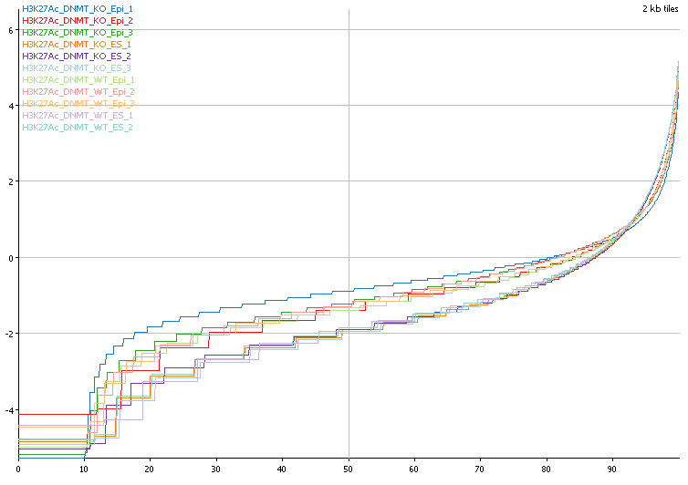

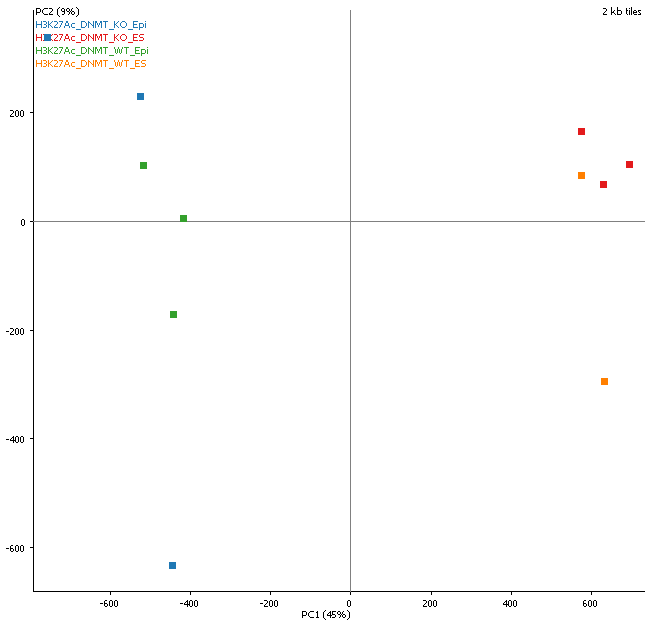

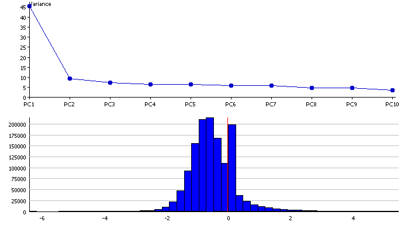

Stark difference between Epi and ES, not so much between WT and KO

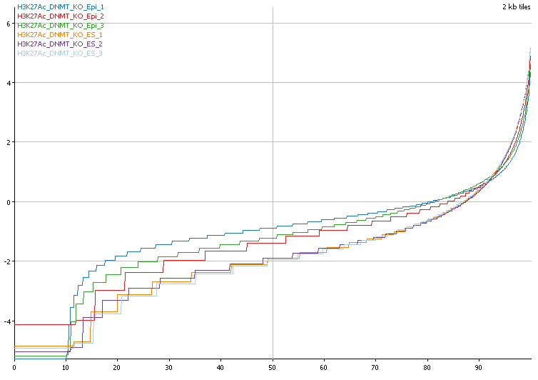

It's indeed Epi and ES which have different cumulative distributions.

Replicate Set Changed

H3K27Ac_DNMT_WT_ES H3K27Ac_DNMT_WT_ES_1 H3K27Ac_DNMT_WT_ES_2 H3K27Ac_DNMT_WT_ES_3

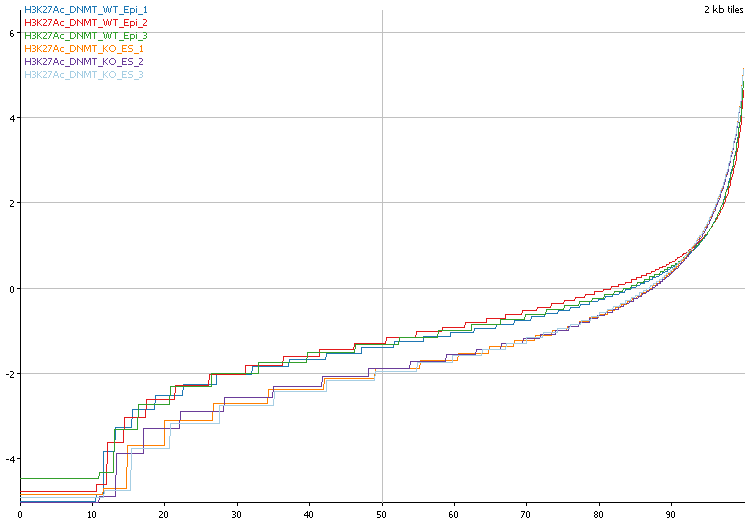

These are really quite different!

This is also good to go.

[figure not shown]